# Various Graph

Samsung Display

2022 5 20

## 원그래프

원 그래프는 특정 변수에 범주별 비율을 보여주는 시각화 방법 중 하나이다. 아래는 다이아몬드의 ggplot을 통해 절단품질 비율을 시각화한 결과이다. 최상급 품질과 프리미엄 품질이 절반 이상을 차지하는 것을 알 수 있다.

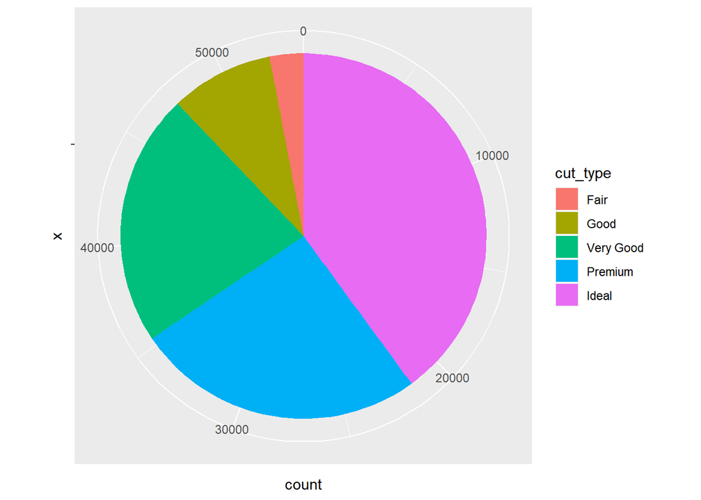

## 도넛 그림

도넛 그림 또한 원 그래프와 마찬가지로 특정 변수에 범주별 비율을 보여주는 시각화 방법 중 하나이다. 도넛 그래프는 여러 변수의 비율을 한번에 보여줄 수 있다는 장점이 있다. 투명도가 나쁠수록 절단품질이 안 좋은 것을 확인할 수 있으며, 투명도가 높을수록 절단품질이 최상급인 자료가 많다는 것을 알 수 있다.

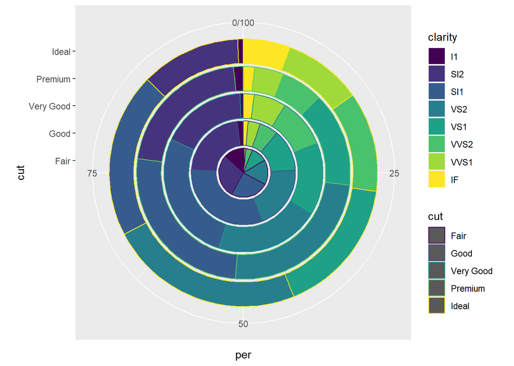

## 막대그래프

막대 그래프는 한 변수 혹은 여러 변수에 대한 빈도나 비율을 보여주는 시각화 방법 중 하나이다.

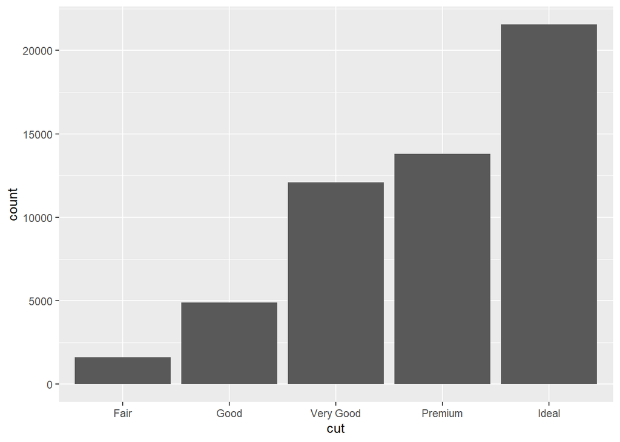

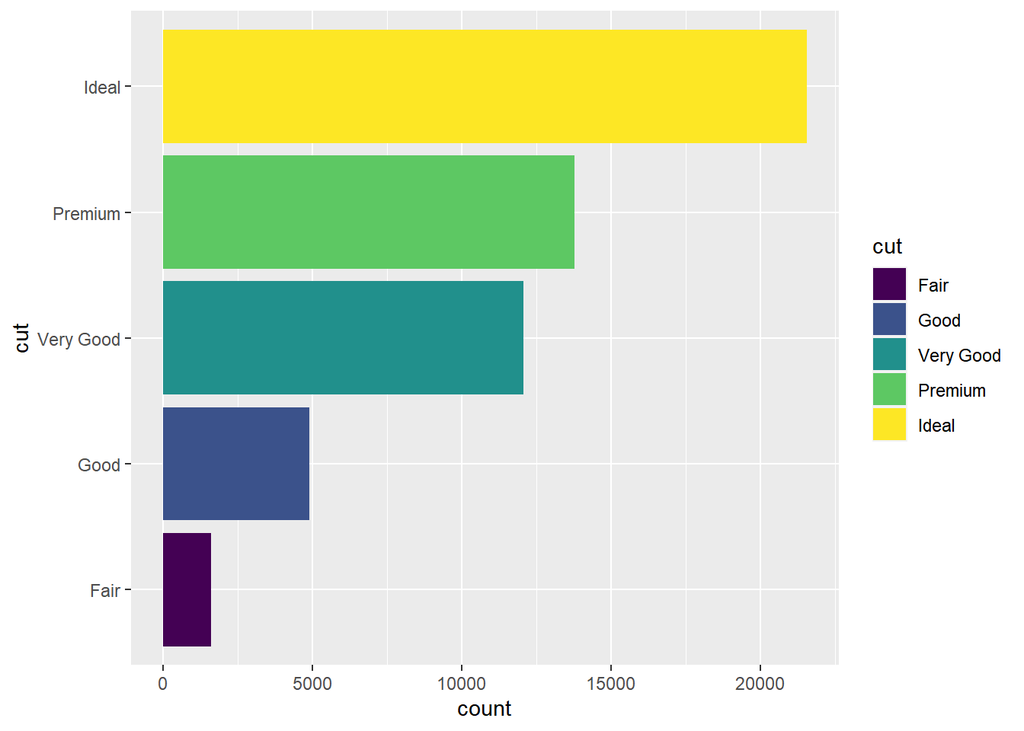

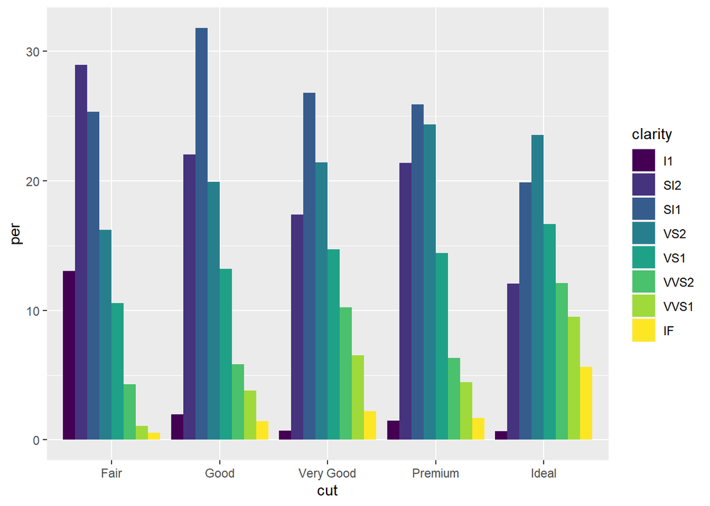

## 히스토그램

히스토그램은 어떤 변수에 대한 구간별 빈도수를 시각화하는 방법이다.

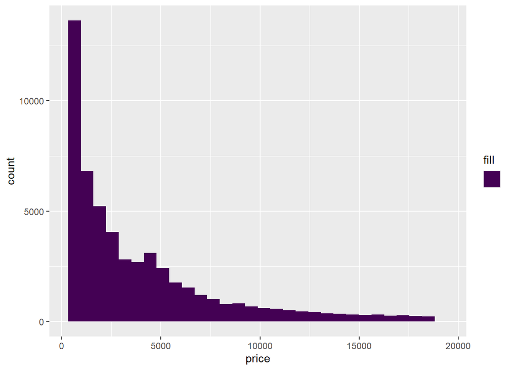

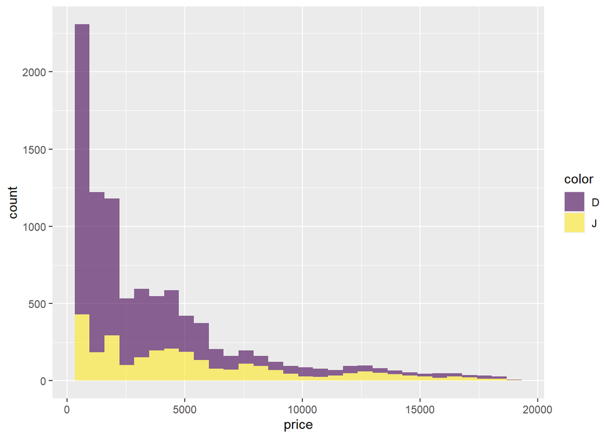

## 밀도분포 그림

밀도 분포 그림은 히스토그램과 유사하나 커널밀도 추정을 통해 자료의 분포를 시각화하는 방법이다. 커널밀도추정은 커널밀도함수를 활용하여 히스토그램을 부드럽게 선으로 나타내는 방법이다. 큰 다이아몬드들은 대체로 투명도가 좋지 않음을 확인할 수 있다.

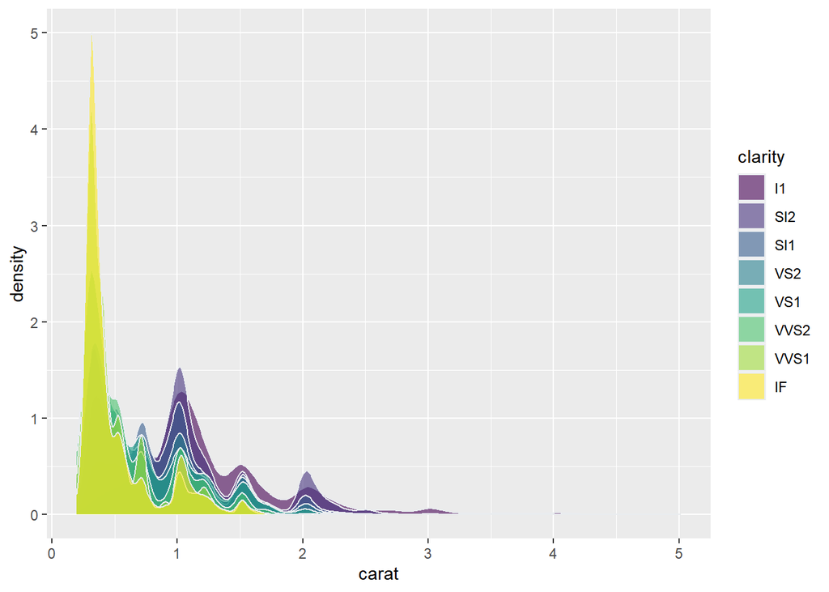

## 상자그림

3사분위(자료 중 75%에 위치한 자료)와 1사분위(자료 중 25%에 위치한 자료)자료의 차이를 기준으로 특정 범위를 산출하여, 그 범위를 넘어서는 자료를 점으로 표기하여 시각화해주는 방법 중 하나이다.

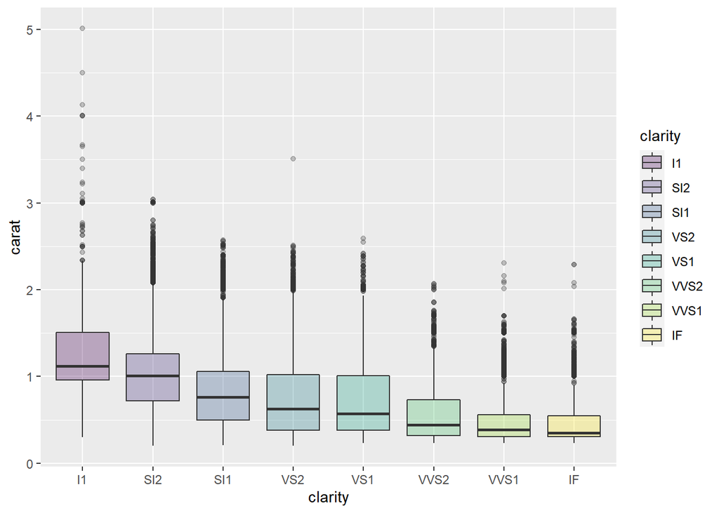

## 바이올린 그림

바이올린 그림 또한 상자그림과 마찬가지로 자료의 분포나 치우침, 이상자료, 대칭성 등을 쉽게 볼 수 있으며, 커널밀도추정을 통해 자료의 분포를 좀 더 정확하게 파악할 수 있다는 특징이 있다.

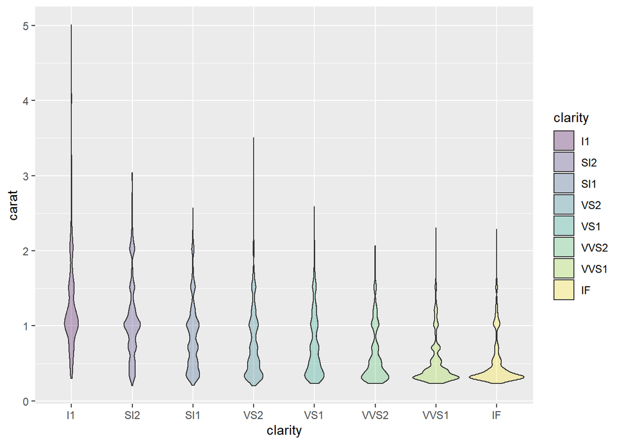

## 산점도

산점도란 직교좌표계를 이용해 좌표 상의 점들을 표시함으로써 두 변수 사이의 관계를 직관적으로 시각화하는 방법이다.

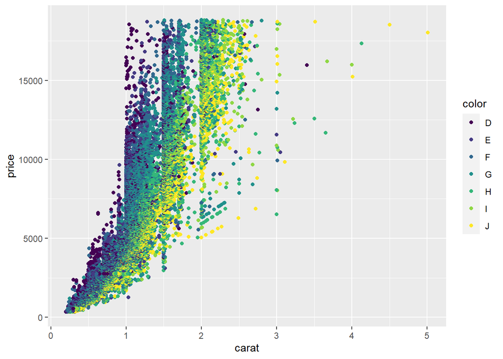

## 시계열 그림

시계열 그림은 시간의 변화에 따른 변수의 변화를 시각화하는 방법 중 하나이다.

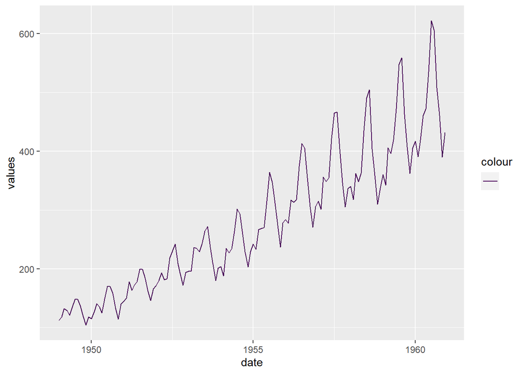

## 모자이크 그림

모자이크 그림은 둘 혹은 새개의 범주형 변수들의 빈도를 가시화하는 방법이다.

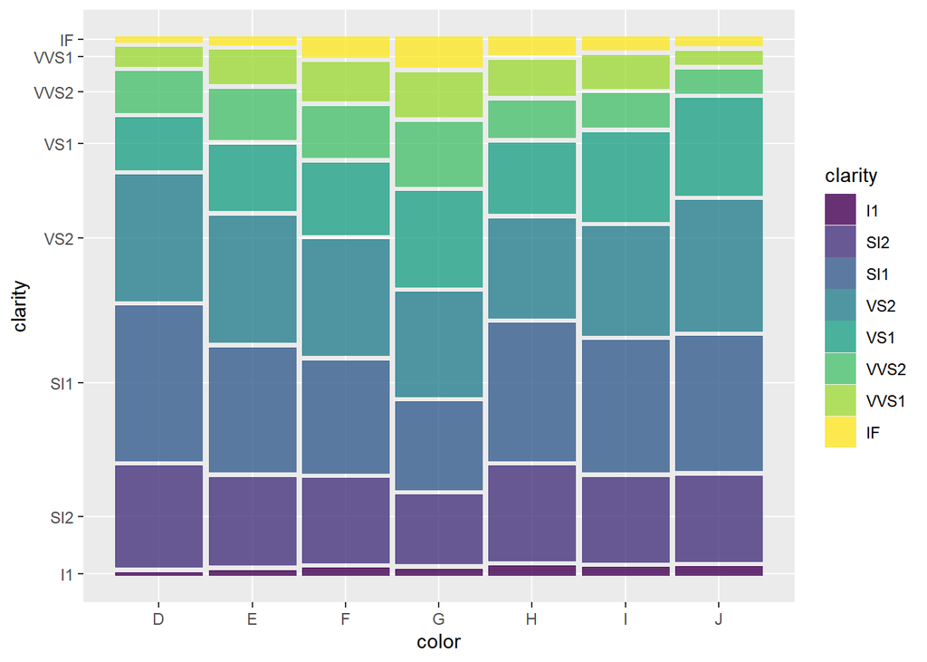

## 상관성 그림

상관성그림은 두 변수 사이의 선형적인 상관성의 정도를 시각화하는 방법이다.

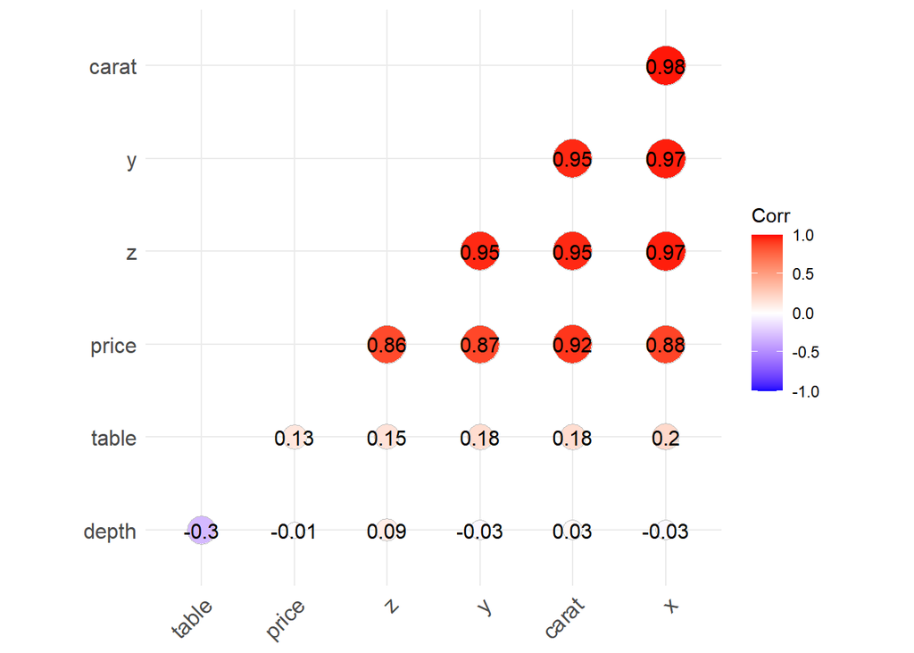

## 워드클라우드

워드클라우드는 자료의 핵심이 되는 단어를 직관적으로 파악할 수 있도록 시각화하는 기법이다.

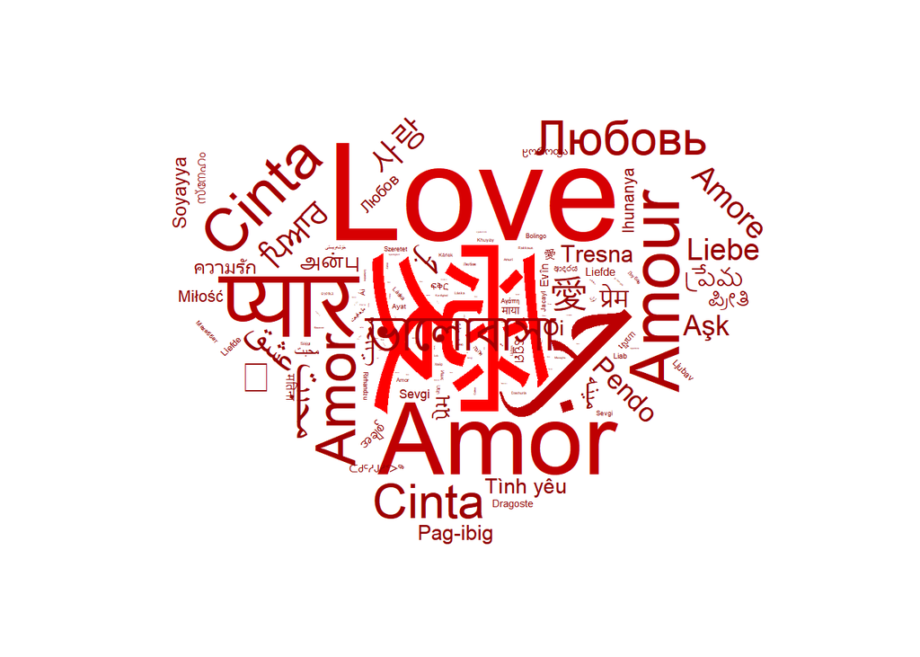

## 사회관계망

사회관계망은 점들 사이의 연관성을 직관적으로 파악할 수 있도록 점 사이의 연관성을 선의 굵기로 시각화하는 기법이다.

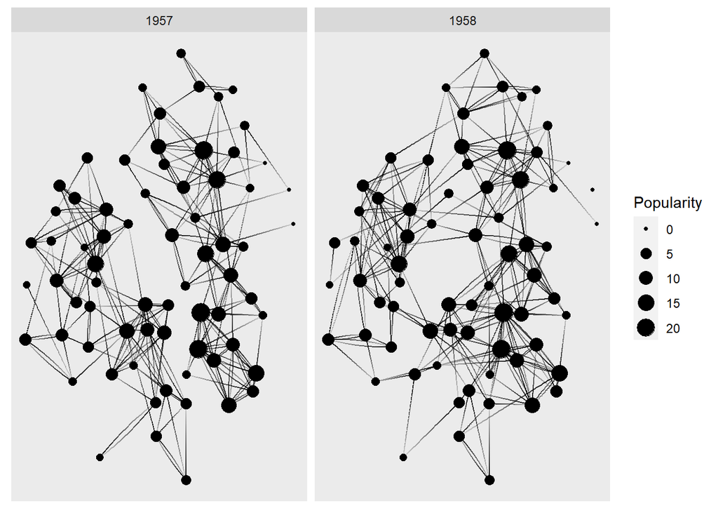

## 퀴버플롯

퀴버플롯은 방향과 크기를 가지는 벡터의 흐름을 직관적으로 시각화하는 방법으로, 풍향/풍속, 유향/유속 등의 자료를 시각화 할 때 주로 활용한다.

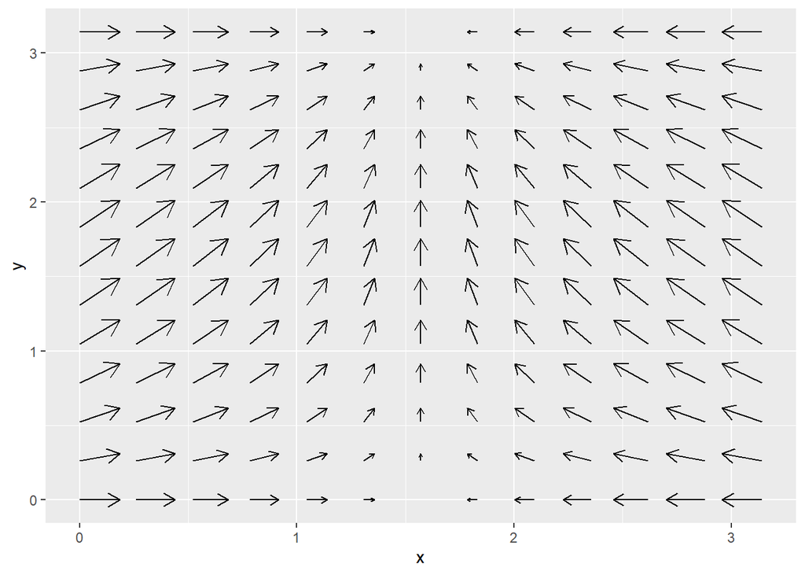

## 바람장미도 바람장미도는 특정 관측지점의 특정 기간동안의 각 방위별 풍향/풍속에 대한 출현 빈도를 방사모양의 그래프로 시각화하는 기법이다.

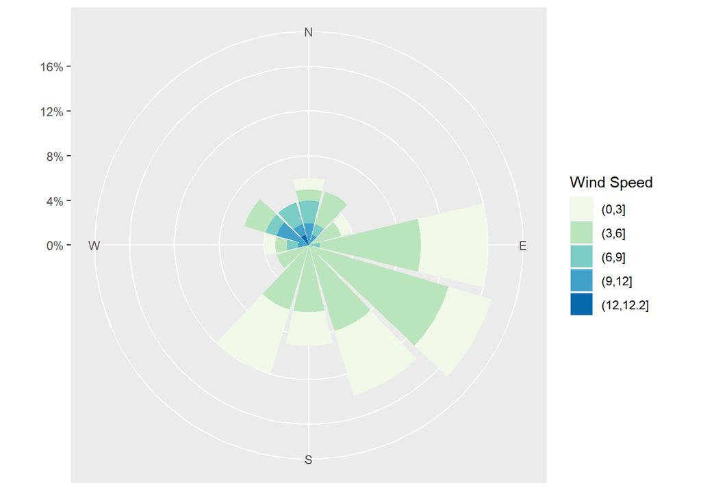

## 2차원 밀도 그림

2차원 밀도그림으로 산점도의 밀도를 색으로 시각화하는 방법이다.

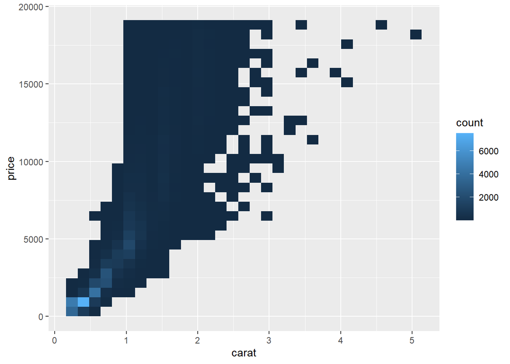

## 좌표 유형(coordinate_fun)

2차원 밀도그림으로 산점도의 밀도를 색으로 시각화하는 방법이다.

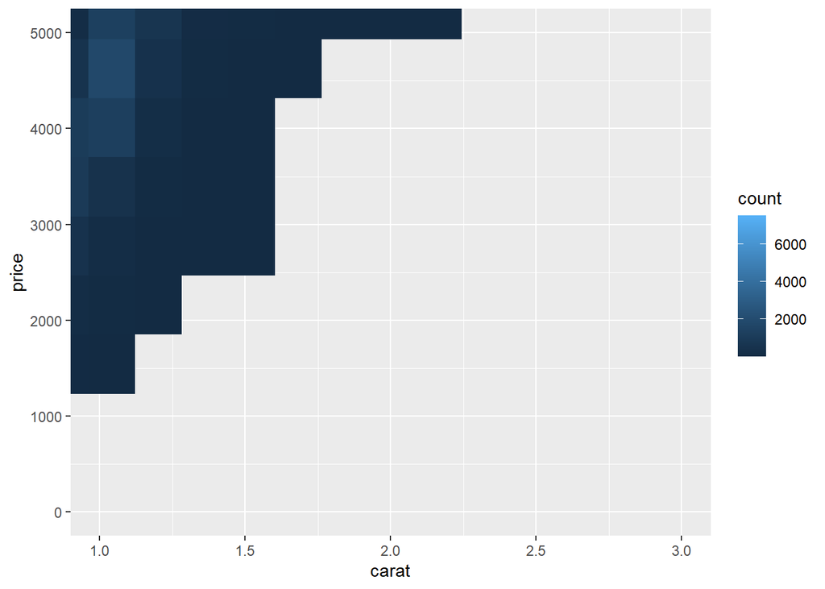

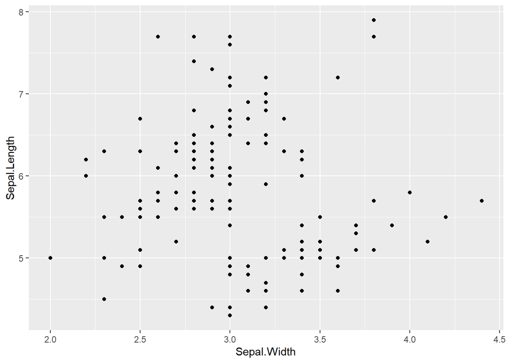

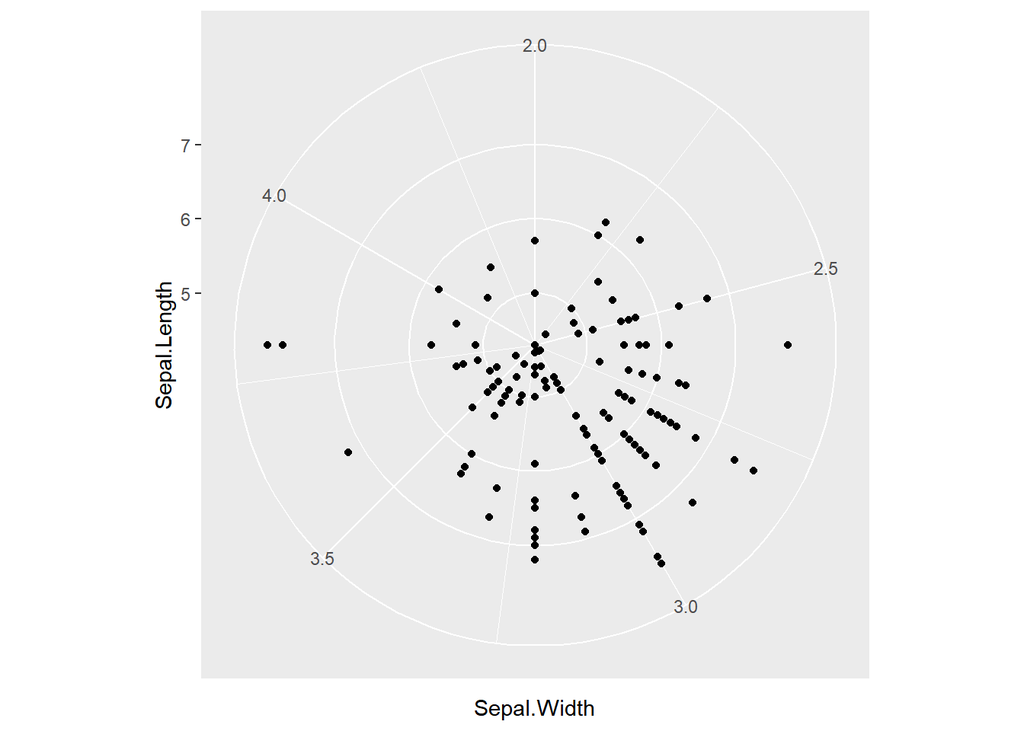

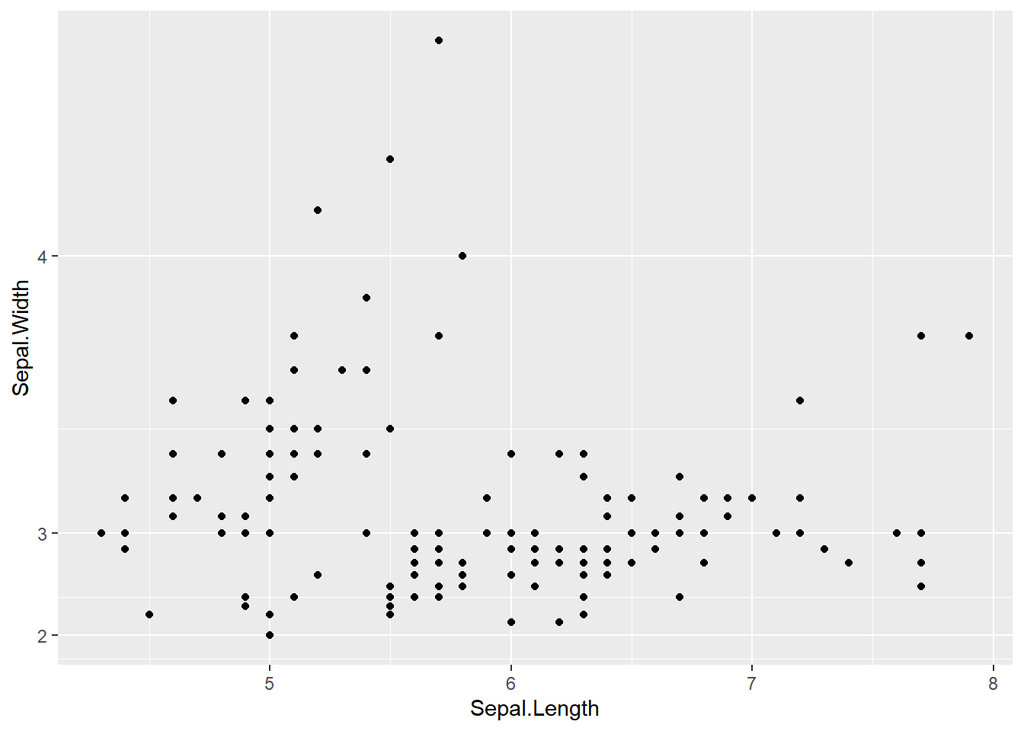

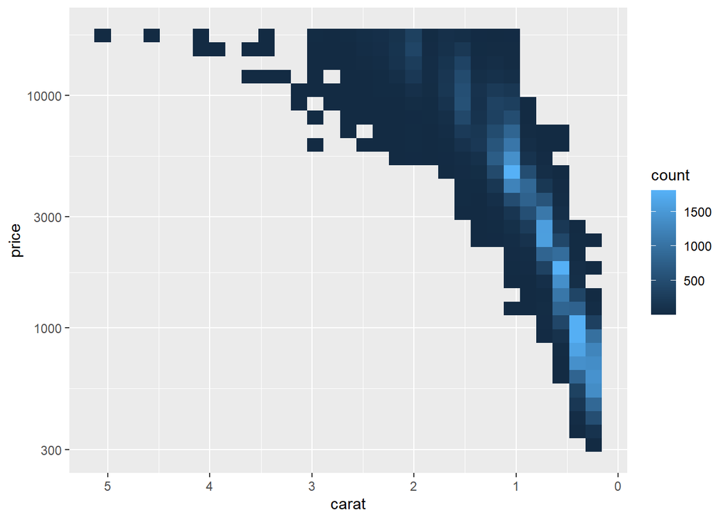